# Appendix A

Model fitting and selection for tracking data

# Overall description

We have used the data collected by Kimberly Holbrook for her studies on toucan home ranges and movement patterns (Holbrook 2011). We cleaned original data similarly, as is shown in the `raw-data/newpointlocs.R` file of this directory, by restricting the individuals to those with a minimum of 40 observations and locations collected in intervals from 15 to 90 minutes in multiples of 15 minutes. As shown in previous studies (Holbrook and Loiselle 2007), the distances traveled by toucans in 15-30 minutes represent the most probable distances for seed dispersal. Due to data collection constraints, locations could not be obtained every 15 minutes, and birds were sometimes located at greater time intervals. Our goal in this section is to use a probabilistic approach that will characterize the pattern of distances moved, and use these probability distributions to later randomly sample distances from. In order to do this, we scaled the original data in distances moved per time interval, to distances moved per minute.

Our approach involves fitting these probability distributions at three different levels: population, individual, and family. In the case of population level fittings, a probability distribution is used to fit all the data available, and a single distribution is used to describe the population’s distanced moved. At the individual level, each bird is analyzed separately and a single distribution is assigned to the data of each individual bird to characterize it’s distances moved. The family level analysis is restricted to the data points for which we have available information on family group. In this case, a single probability distribution is used for each individual family group to describe the distances moved.

Due to the fact that data was collected at different tracking intervals, we scaled it to represent number of meters moved per minute. The goal of these fittings is to obtain parameters of probability distributions that can describe how fast these animals are moving, so that in simulations, we can use these distributions for random sampling of speeds when the animals are moving.

Density plots showing variation in biological classification levels, where the red line shows the density plot for what we consider the population (all the data together), and grey lines show individuals (left) or family groups (right).

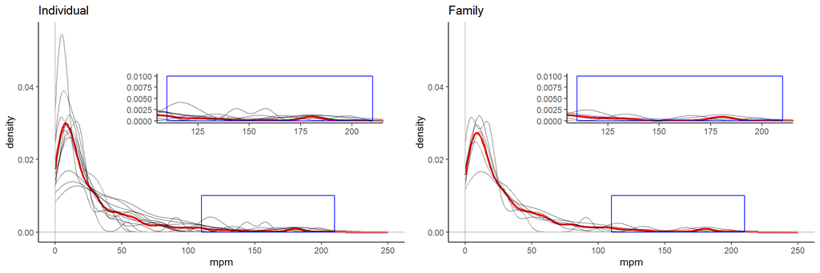

# Population and Individual level comparisons

At the population level analysis, we observe that the lognormal distribution has considerable overestimation of distances towards the tail. Although this is also worth noting in the QQ plots for individuals, not all of the individuals have an overestimation, and for some individuals, other distributions seem to do a better job at characterizing the pattern.

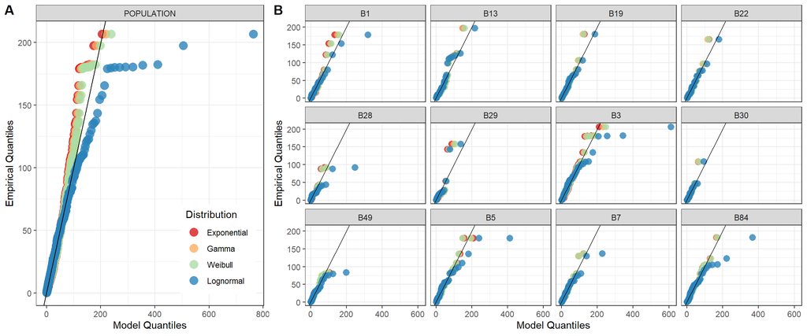

## Information criteria comparisons

At the population level, we compared the fit between the four distribution models using different information criteria (AIC, AICc, and BIC). At the individual level we considered five different models, four of these models corresponded to each of the four probability distributions, were we essentially allowed for individuals to change parameters, but the overall shape of the distribution was the same. For the first four models, we assumed that one probability distribution could accurately describe the movement rates for each individual by changing the distribution’s parameters. A fifth alternative model considered instead the best fitting model for each individual and calculated the overall information criteria as a combination of the best fitting model for each individual. For each of these individual level models, information criteria were calculated based on the number of parameters, sample size and negative log likelihood in the following way

$$AIC{_{indlevel}} = 2\cdot \sum \left ( number parameters \right ) + 2\cdot \sum \left ( -\ln\mathcal{L}() \right )$$

$$AICc{_{indlevel}} = AIC{_{indlevel}} + (2 \cdot \sum{nparams} \cdot \left(\sum{nparams}+1\right)/\left(\sum{observations} - \left(\sum{nparams} - 1\right)\right)$$

$$BIC_{indlevel} = \ln{\sum observations(samplesize)} \cdot \sum{number parameters} + 2\cdot \sum {negative log likelihood}$$

The three information criteria differ in their model choices, with AIC and corrected AIC (AICc) selecting the same models, and BIC selecting different ones.

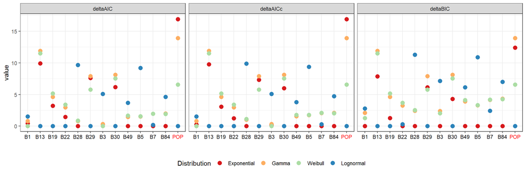

**Model comparisons across levels**

| Model | **BIC** BIC | **BIC** Δ BIC<sub>within</sub> | **BIC** Δ BIC<sub>across</sub> | **AIC** AIC | **AIC** Δ AIC<sub>within</sub> | **AIC** Δ AIC<sub>across</sub> |
| --- | --- | --- | --- | --- | --- | --- |
| Population |  |  |  |  |  |  |
| Exponential | 5771.927 | 12.0 | 12.0 | 5767.430 | 17.0 | 75 |
| Gamma | 5773.431 | 14.0 | 14.0 | 5764.437 | 14.0 | 72 |
| Weibull | 5766.104 | 6.6 | 6.6 | 5757.111 | 6.6 | 65 |
| Lognormal | 5759.524 | 0.0 | 0.0 | 5750.530 | 0.0 | 59 |
| Individual |  |  |  |  |  |  |
| Exponential | 5775.039 | 0.0 | 16.0 | 5721.078 | 0.0 | 29 |
| Gamma | 5844.348 | 69.0 | 85.0 | 5736.426 | 15.0 | 44 |
| Weibull | 5841.288 | 66.0 | 82.0 | 5733.366 | 12.0 | 41 |
| Lognormal | 5833.851 | 59.0 | 74.0 | 5725.928 | 4.9 | 34 |
| Multidist |  |  |  |  |  |  |
| Multidist | 5766.134 | NA | 6.6 | 5691.979 | NA | 0 |

## Probability distribution parameters

We can compare the different parameter values estimated for each distribution and their standard deviations. These parameters can give us some insight into some of the characteristics of each set of distances moved per minute, such as which individuals have higher means or longer tails in the distribution of their distances moved per minute. The x axis in the following plots highlights which individuals have the lowest BIC (yellow) or AIC(magenta) with that model. The blue lines show the value of that parameter for the population level model, and dashed blue lines show the upper and lower limits of that parameter estimate. Overall, at the population level, the lognormal model had the lowest AIC and BIC values.

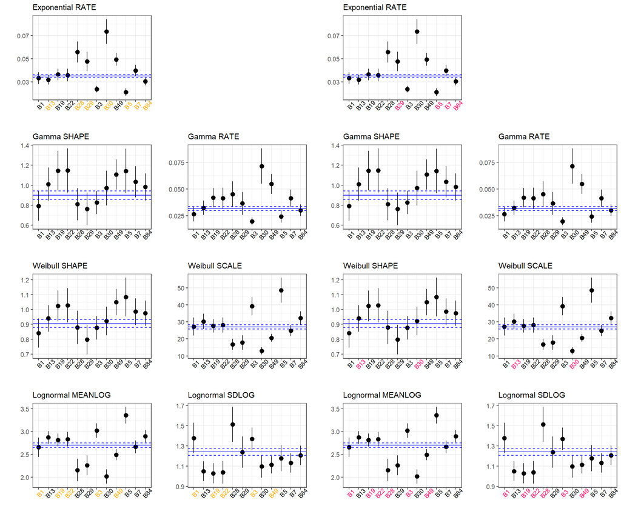

Summary: When comparing population vs individual level fits, at the population level, the lognormal distribution fits the data better, and at the individual level it is the exponential distribution. This is shown by both AIC and BIC levels. When we focus only on the individual level fits, which distribution fits best depends on the information criteria considered, although most of the individuals are properly characterized by an exponential or lognormal distribution. What we consider as the multi distribution, it is a multi-distribution probability fit to the data in which we have allowed not only the parameters but also the shape of the distribution to vary between individuals. This means that each individual can be characterized by a different distribution and different parameters. In the case of AIC and AICc, this probability approach works best for the data, however when considering BIC, the lognormal fit is best, and the mixed distribution approach ties with a Weibull distribution at population level.

# Population vs Family

## Population level - restricted

Keep in mind that the family level data is reduced because some individuals had unknown family groups and therefore are not included in this analysis.This means that we cannot directly compare distribution fits from family level aggregation with that of individuals. To make a comparison with the population, we need to keep only data points for which we have family information

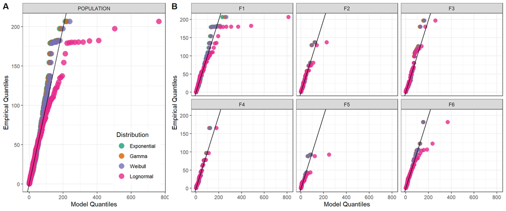

The three information criteria differ in their model choices, with AIC and corrected AIC (AICc) selecting the same models, and BIC selecting different ones.

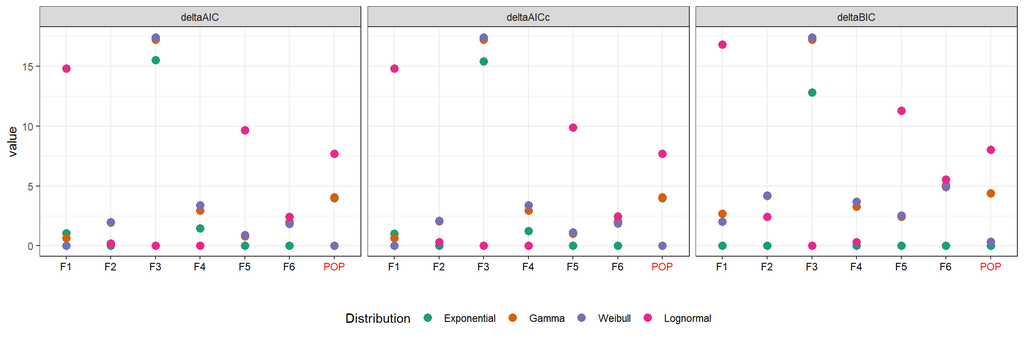

**Model comparisons across levels**

| Model | **BIC** BIC | **BIC** Δ BIC<sub>within</sub> | **BIC** Δ BIC<sub>across</sub> | **AIC** AIC | **AIC** Δ AIC<sub>within</sub> | **AIC** Δ AIC<sub>across</sub> |
| --- | --- | --- | --- | --- | --- | --- |
| Population |  |  |  |  |  |  |
| Exponential | 5141.259 | 0.00 | 8.0 | 5136.891 | 4.0 | 37 |
| Gamma | 5145.662 | 4.40 | 12.0 | 5136.926 | 4.0 | 37 |
| Weibull | 5141.624 | 0.36 | 8.4 | 5132.888 | 0.0 | 33 |
| Lognormal | 5149.303 | 8.00 | 16.0 | 5140.566 | 7.7 | 40 |
| Family Group |  |  |  |  |  |  |
| Exponential | 5144.355 | 0.00 | 11.0 | 5118.145 | 0.0 | 18 |
| Gamma | 5178.134 | 34.00 | 45.0 | 5125.716 | 7.6 | 26 |
| Weibull | 5177.979 | 34.00 | 45.0 | 5125.561 | 7.4 | 25 |
| Lognormal | 5179.624 | 35.00 | 46.0 | 5127.206 | 9.1 | 27 |
| Multidist |  |  |  |  |  |  |
| Multidist | 5133.212 | NA | 0.0 | 5100.118 | NA | 0 |

## Probability distribution parameters

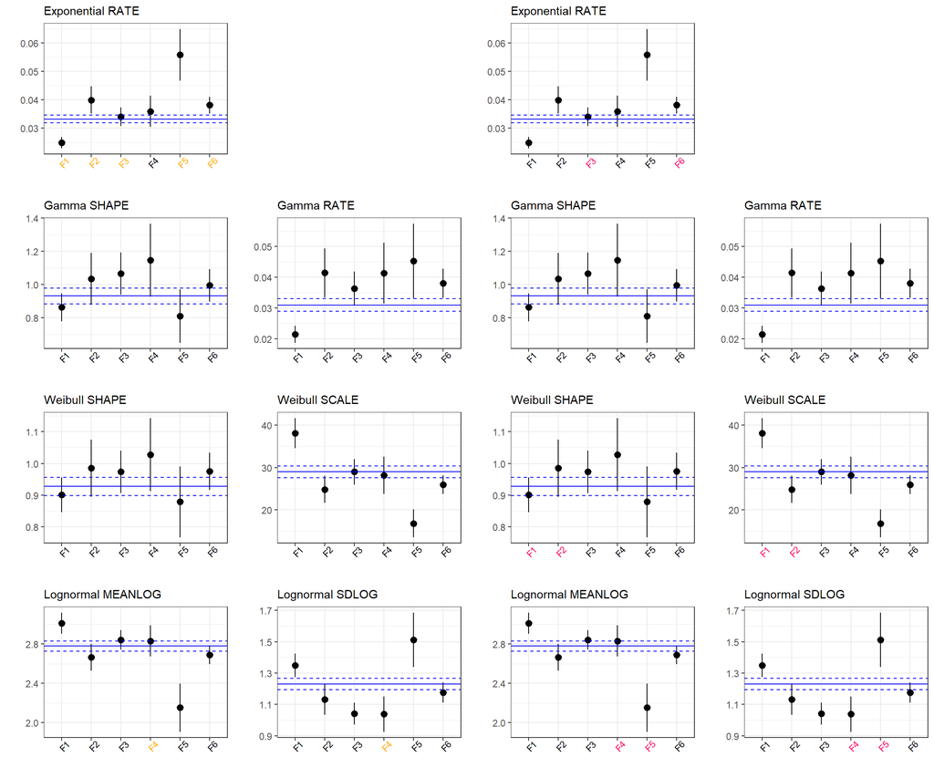

Summary. As with individuals, the information criteria actually changes things a lot. With AIC and AICc, family level aggregation is a better descriptor of the data, no matter the distribution used, whereas in BIC it is the opposite and population level data is best for all distributions. However, the multidistribution approach, where each family is characterized by its own independent distribution and parameters, no matter the information criteria, this one comes with the lowest value, making the multidistribution approach the best for characterizing the data.

# References

Holbrook, Kimberly M. 2011. “Home Range and Movement Patterns of Toucans: Implications for Seed Dispersal.” *Biotropica* 43 (3): 357–64. https://doi.org/10.1111/j.1744-7429.2010.00710.x.

Holbrook, K. M., and B. A. Loiselle. 2007. “Using Toucan-Generated Dispersal Models to Estimate Seed Dispersal in Amazonian Ecuador.” In *Seed Dispersal: Theory and Its Application in a Changing World*, 300–321. CAB International, Wallingford.

Jones, Landon R., Scott M. Duke‐Sylvester, Paul L. Leberg, and Derek M. Johnson. 2017. “Closing the Gaps for Animal Seed Dispersal: Separating the Effects of Habitat Loss on Dispersal Distances and Seed Aggregation.” *Ecology and Evolution* 7 (14): 5410–25. https://doi.org/10.1002/ece3.3113.

Levey, Douglas J., Benjamin M. Bolker, Joshua J. Tewksbury, Sarah Sargent, and Nick M. Haddad. 2005. “Effects of Landscape Corridors on Seed Dispersal by Birds.” *Science* 309 (5731): 146–48. https://doi.org/10.1126/science.1111479.

Morales, Juan Manuel, and Tomás A. Carlo. 2006. “The Effects of Plant Distribution and Frugivore Density on the Scale and Shape of Dispersal Kernels.” *Ecology* 87 (6): 1489–96. https://doi.org/10.1890/0012-9658(2006)87[1489:TEOPDA]2.0.CO;2.